# R Notebook

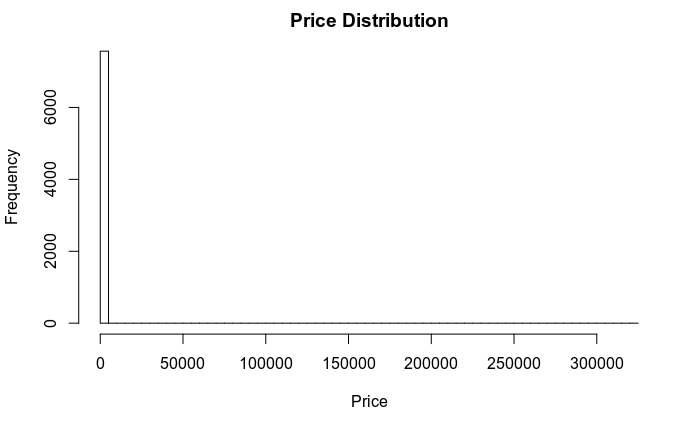

```r
hist(finviz$Price, breaks=100, main="Price Distribution", xlab="Price")
```

As we can see the graph isn’t worth it due to higher price in outliers Therefore we try adding a upper limit of $150.

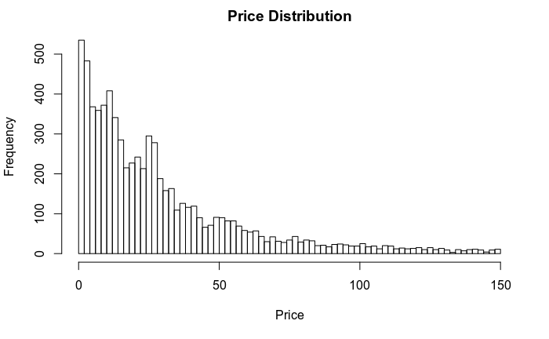

This graph is much better than the previous one and tells us that majority of stocks in our dataset are under $50 We shouldn’t be so sure about this graph, as what if with low prices there are low quality products or the competitors have a high price. Therefore we will try getting average prices by business sector and how they compare.

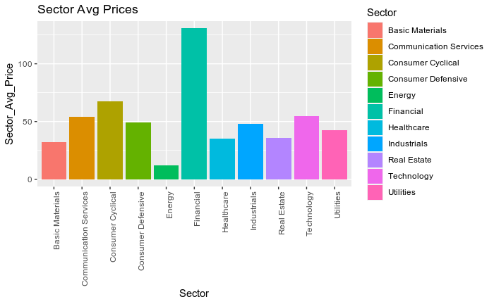

```r
ggplot(sector_avg_prices, aes(x=Sector, y=Sector_Avg_Price,fill=Sector)) +
    geom_bar(stat="identity") + ggtitle("Sector Avg Prices") +
    theme(axis.text.x = element_text(angle = 90, hjust = 1))
```

As we can see clearly , Financial sector has significantly higher prices than other sectors. What is the reason, lets see

We create a chart showing avg prices of industry in financial sector

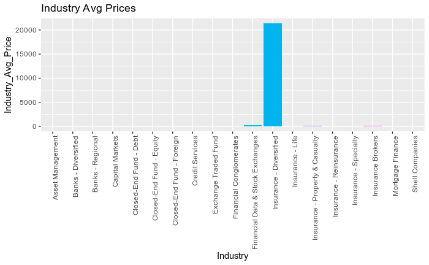

```r
ggplot(industry_chart, aes(x=Industry, y=Industry_Avg_Price, fill=Industry)) +
    geom_bar(stat="identity") + theme(legend.position="none") +
    ggtitle("Industry Avg Prices") +
    theme(axis.text.x = element_text(angle = 90, hjust = 1))
```

Wow!! As we can see Insurance Diversified stocks are crazy high !! So, this is the main culprit for giving financial sector a boost for sector_avg_price Let’s research some more

Exploring the companies in the Industry “Industry - Diversifies”

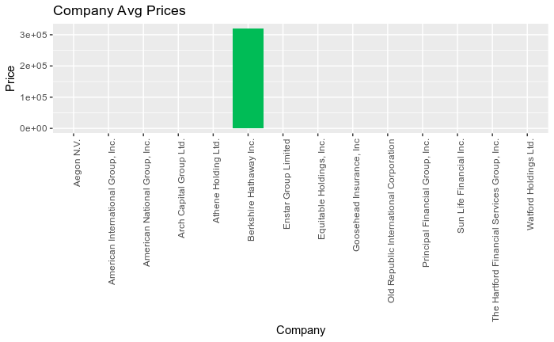

```r
ggplot(company_chart, aes(x=Company, y=Price, fill=Company)) +
    geom_bar(stat="identity") + theme(legend.position="none") +
    ggtitle("Company Avg Prices") +
    theme(axis.text.x = element_text(angle = 90, hjust = 1))
```

Well there are a few companies, but we can see clearly who leads thes industry, it is none other than “Berkshire Hathaway Inc.” Currently their stock price is greter than 3e+05 per share. Whewww… That’s a lot.

Lets remove this from our list and lets see what happens.

After removal, and drawing the graph again for sector_avg_price

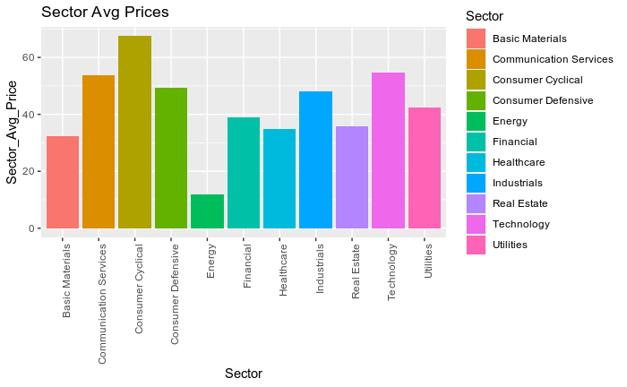

```r
ggplot(sector_avg_prices, aes(x=Sector, y=Sector_Avg_Price, fill=Sector)) +
    geom_bar(stat="identity") + ggtitle("Sector Avg Prices") +
    theme(axis.text.x = element_text(angle = 90, hjust = 1))
```

After various claculations and steps, refer R script file

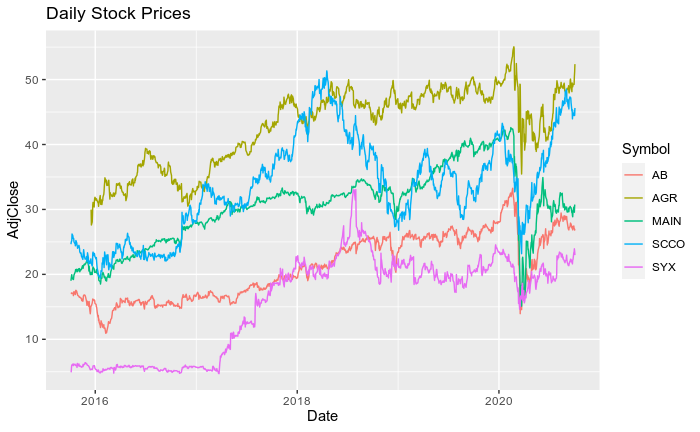